# Ch3: Linear Regression Applied Exercises

Kylie

30/03/2019

## Exercise 8

This question involves the use of simple linear regression on the `Auto` data set.

**(a) Use the `lm()` function to perform a simple linear regression with `mpg` as the response and `horsepower` as the predictor.** Use the `summary()` function to print the results. Comment on the output.

```r
lm_Auto <- lm(mpg ~ horsepower, data = Auto)

summary(lm_Auto)
```

```
##
## Call:
## lm(formula = mpg ~ horsepower, data = Auto)
##
## Residuals:
##      Min       1Q   Median       3Q      Max
## -13.5710  -3.2592  -0.3435   2.7630  16.9240
##
## Coefficients:
##              Estimate Std. Error t value Pr(>|t|)
## (Intercept) 39.935861   0.717499   55.66   <2e-16 ***
## horsepower  -0.157845   0.006446  -24.49   <2e-16 ***
## ---
## Signif. codes:  0 '***' 0.001 '**' 0.01 '*' 0.05 '.' 0.1 ' ' 1
##
## Residual standard error: 4.906 on 390 degrees of freedom
## Multiple R-squared:  0.6059, Adjusted R-squared:  0.6049
## F-statistic: 599.7 on 1 and 390 DF,  p-value: < 2.2e-16
```

For example:

**i. Is there a relationship between the predictor and the response?**

Yes there is a statistically significant relationship between the predictor and the response.

**ii. How strong is the relationship between the predictor and the response?**

Does this refer to the statistical significance or the size of the effect?

A one unit change in horsepower causes a 0.15 unit decrease in miles per gallon. Since the range of `mpg` is 9, 46.6 then this doesn’t seem like a large/strong effect.

**iii. Is the relationship between the predictor and the response positive or negative?**

Negative.

**iv. What is the predicted `mpg` associated with a `horsepower` of 98? What are the associated 95% confidence and prediction intervals?**

```r
predict(lm_Auto, data.frame(horsepower = 98), interval = "confidence") # produces confidence intervals for the prediction of medv for a given value of horsepower
```

```
##        fit      lwr      upr
## 1 24.46708 23.97308 24.96108
```

```r
predict(lm_Auto, data.frame(horsepower = 98), interval = "prediction") # produces prediction intervals for the prediction of medv for a given value of horsepower
```

```
##        fit     lwr      upr
## 1 24.46708 14.8094 34.12476
```

**(b) Plot the response and the predictor. Use the `abline()` function to display the least squares regression line.**

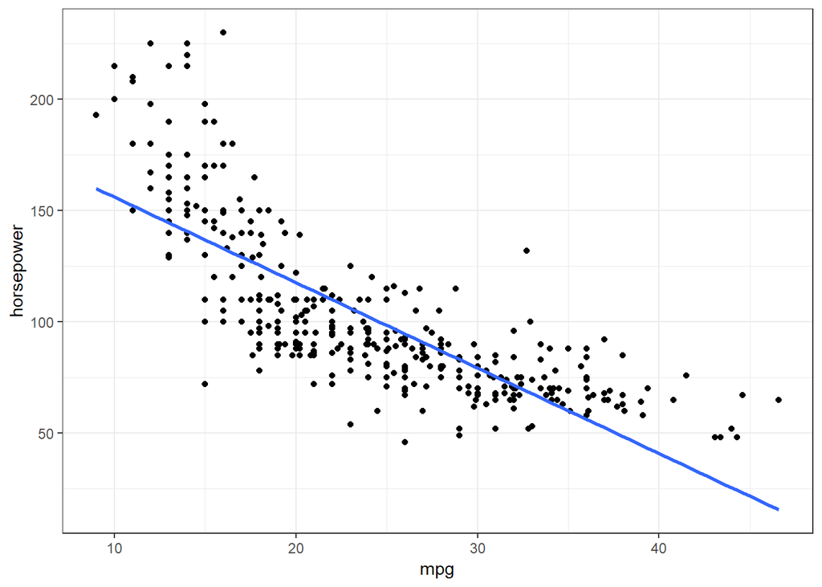

```r
# ggplot alternative:
theme_set(theme_bw()) # setting theme to black and white

ggplot(Auto, aes(x = mpg, y = horsepower)) +
  geom_point() +
  geom_smooth(method = "lm", se = FALSE)
```

**(c) Use the `plot()` function to produce diagnostic plots of the least squares regression fit. Comment on any problems you see with the fit.**

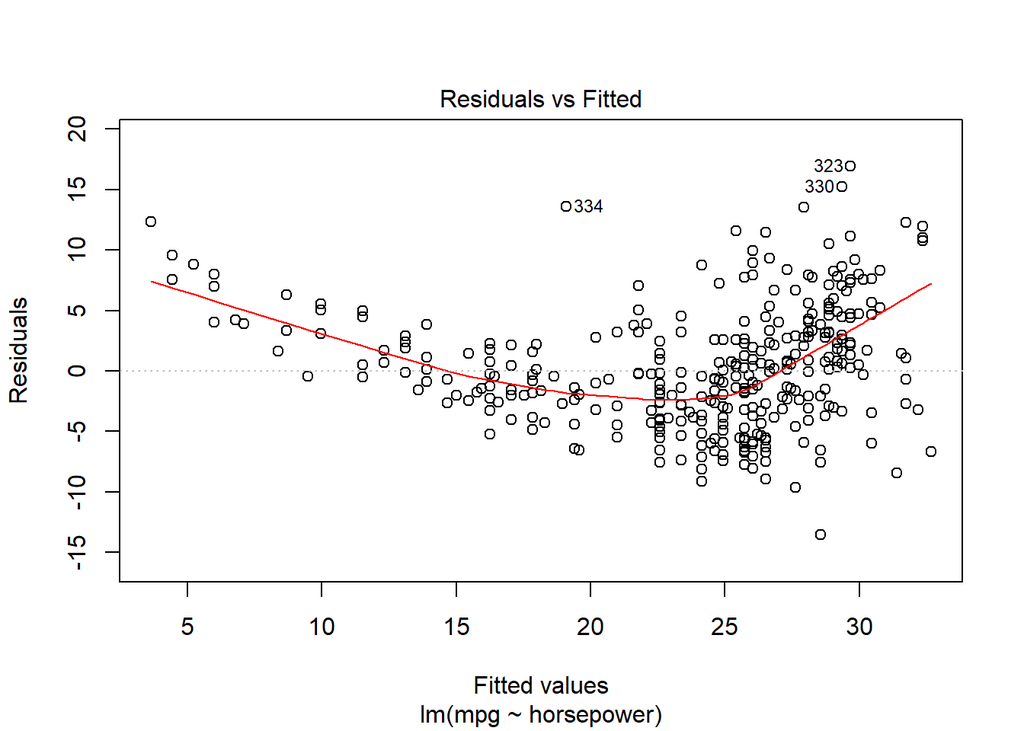

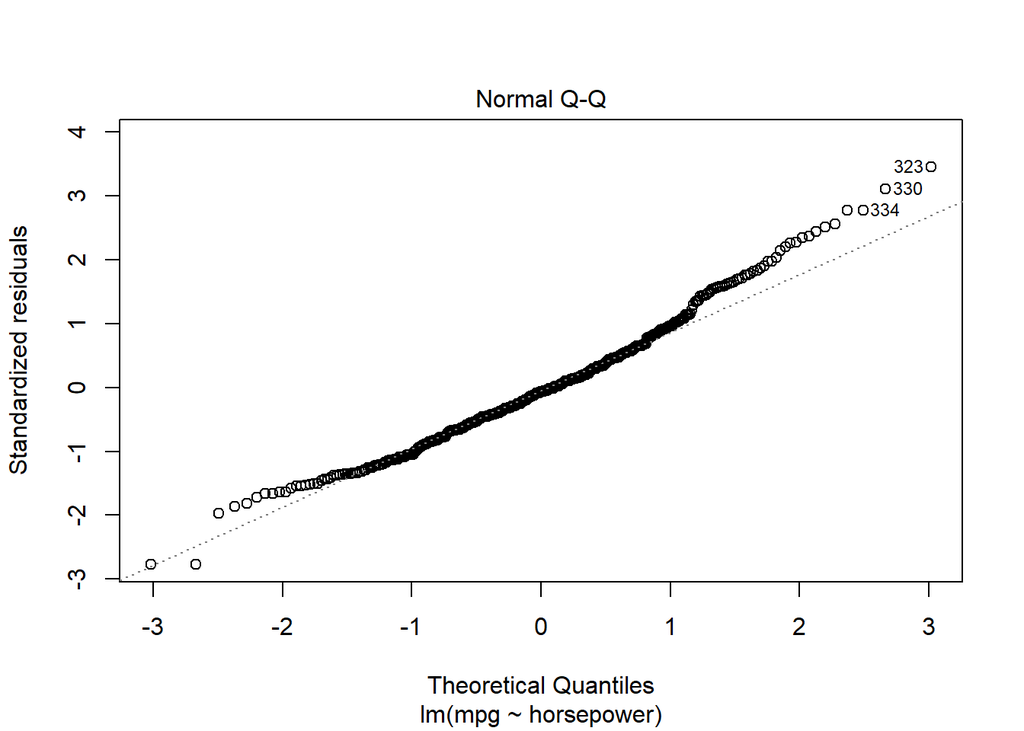

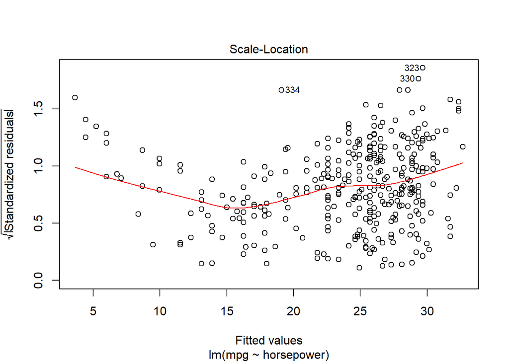

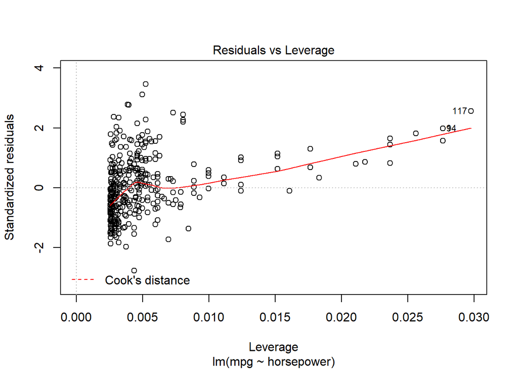

```r
# par(mfrow = c(2,2)) # divides the plotting region into a 2 × 2 grid of panels
plot(lm_Auto) # plotting diagnostic plots
```

There is a nonlinear relationship between `mpg` and `horsepower` that is not captured by the linear model. The residuals are slightly non-normally distributed.

## Exercise 9

This question involves the use of multiple linear regression on the `Auto` data set.

**(a) Produce a scatterplot matrix which includes all of the variables in the data set.**

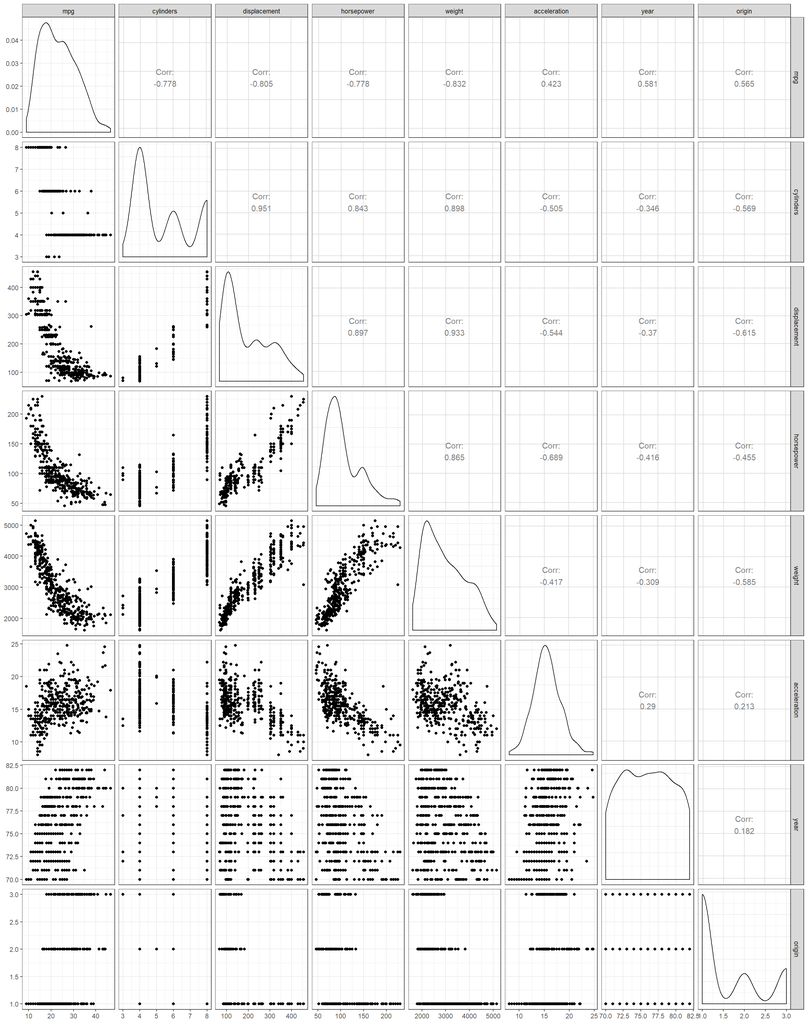

```r
ggpairs(select(Auto, -name)) # scatterplot matrix of all variables except 'name'
```

**(b) Compute the matrix of correlations between the variables using the function `cor()`. You will need to exclude the `name` variable, which is qualitative.**

```r
(cor_Auto <- cor(select(Auto, -name))) # correlation matrix between all variables except 'name'
```

```
##                     mpg  cylinders displacement horsepower     weight
## mpg           1.0000000 -0.7776175   -0.8051269 -0.7784268 -0.8322442
## cylinders    -0.7776175  1.0000000    0.9508233  0.8429834  0.8975273
## displacement -0.8051269  0.9508233    1.0000000  0.8972570  0.9329944
## horsepower   -0.7784268  0.8429834    0.8972570  1.0000000  0.8645377
## weight       -0.8322442  0.8975273    0.9329944  0.8645377  1.0000000
## acceleration  0.4233285 -0.5046834   -0.5438005 -0.6891955 -0.4168392
## year          0.5805410 -0.3456474   -0.3698552 -0.4163615 -0.3091199
## origin        0.5652088 -0.5689316   -0.6145351 -0.4551715 -0.5850054
##              acceleration       year     origin
## mpg             0.4233285  0.5805410  0.5652088
## cylinders      -0.5046834 -0.3456474 -0.5689316
## displacement   -0.5438005 -0.3698552 -0.6145351
## horsepower     -0.6891955 -0.4163615 -0.4551715
## weight         -0.4168392 -0.3091199 -0.5850054
## acceleration    1.0000000  0.2903161  0.2127458
## year            0.2903161  1.0000000  0.1815277
## origin          0.2127458  0.1815277  1.0000000
```

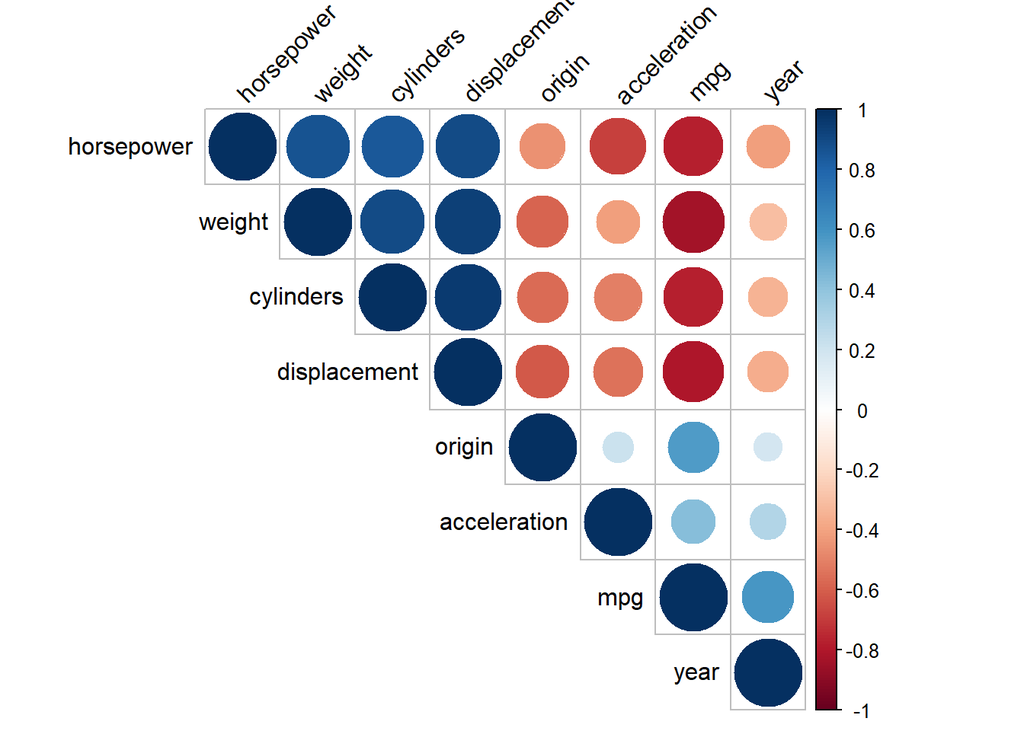

```r
corrplot(cor_Auto, type = "upper", order = "hclust",
         tl.col = "black", tl.srt = 45) # plots a correlogram
```

**(c) Use the `lm()` function to perform a multiple linear regression with `mpg` as the response and all other variables except `name` as the predictors. Use the `summary()` function to print the results.**

```r
lm_Auto_mult <- lm(mpg ~. -name, data = Auto) # multiple linear regression with mpg as response and all other variables except 'name' as predictors

summary(lm_Auto_mult)
```

```
##
## Call:
## lm(formula = mpg ~ . - name, data = Auto)
##
## Residuals:
##     Min      1Q  Median      3Q     Max
## -9.5903 -2.1565 -0.1169  1.8690 13.0604
##
## Coefficients:
##                Estimate Std. Error t value Pr(>|t|)
## (Intercept)  -17.218435   4.644294  -3.707  0.00024 ***
## cylinders     -0.493376   0.323282  -1.526  0.12780
## displacement   0.019896   0.007515   2.647  0.00844 **
## horsepower    -0.016951   0.013787  -1.230  0.21963
## weight        -0.006474   0.000652  -9.929  < 2e-16 ***
## acceleration   0.080576   0.098845   0.815  0.41548
## year           0.750773   0.050973  14.729  < 2e-16 ***
## origin         1.426141   0.278136   5.127 4.67e-07 ***
## ---
## Signif. codes:  0 '***' 0.001 '**' 0.01 '*' 0.05 '.' 0.1 ' ' 1
##
## Residual standard error: 3.328 on 384 degrees of freedom
## Multiple R-squared:  0.8215, Adjusted R-squared:  0.8182
## F-statistic: 252.4 on 7 and 384 DF,  p-value: < 2.2e-16
```

**Comment on the output. For instance:**

**i. Is there a relationship between the predictors and the response?**

Yes there is a relationship between the predictors and the response. The F-statistic has a very low p-value.

**ii. Which predictors appear to have a statistically significant relationship to the response?**

`displacement`, `weight`, `year`, and `origin`.

**iii. What does the coefficient for the year variable suggest?**

A one year increase in the variable `year` is associated with a 0.75 unit increase in miles per gallon.

**(d) Use the `plot()` function to produce diagnostic plots of the linear regression fit.** Comment on any problems you see with the fit. Do the residual plots suggest any unusually large outliers? Does the leverage plot identify any observations with unusually high leverage?

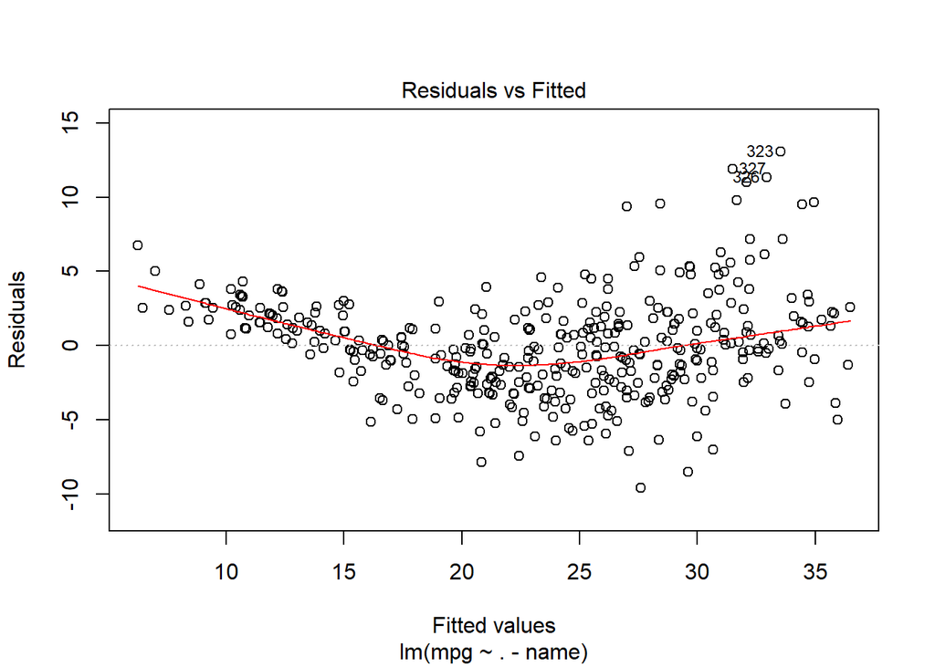

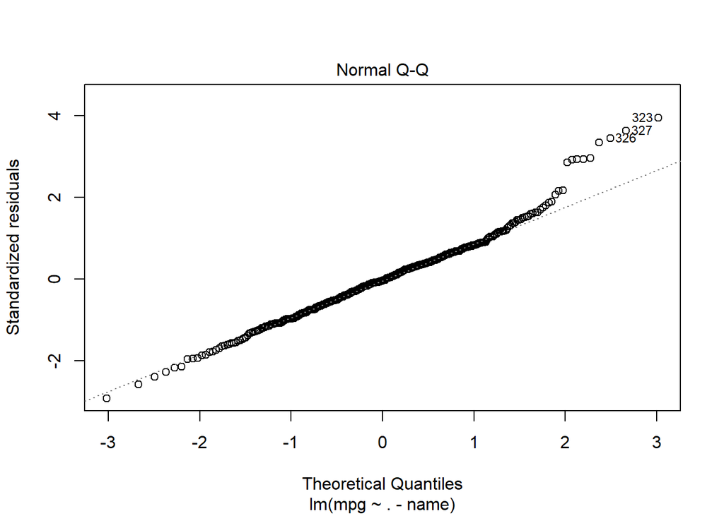

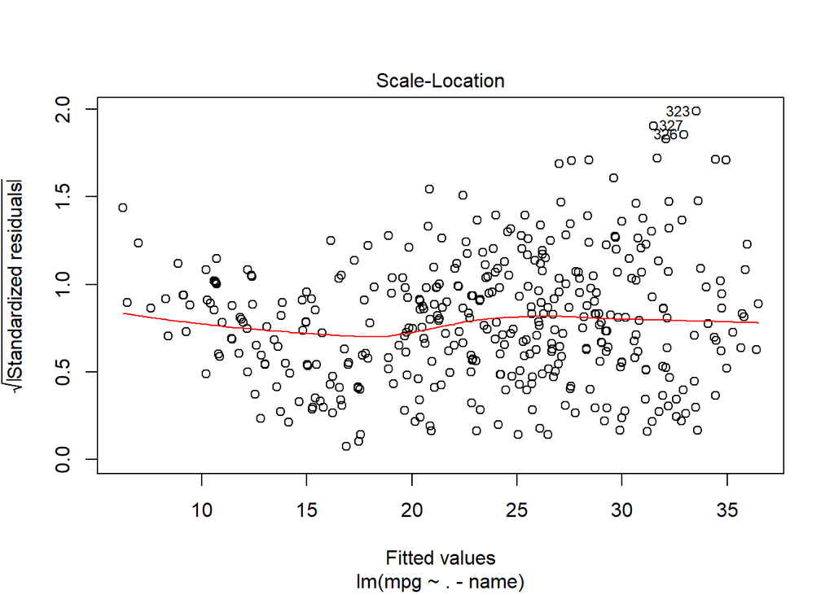

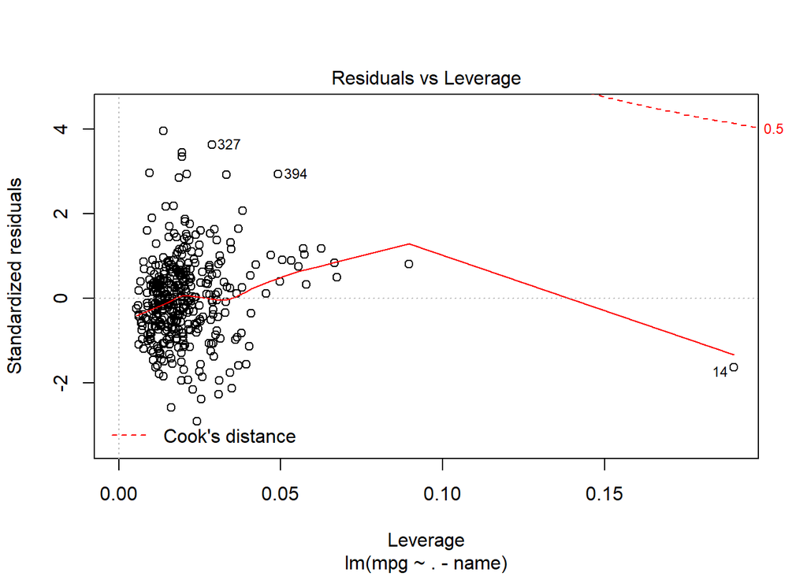

```r
plot(lm_Auto_mult) # diagnostic plots
```

There is a slight nonlinear trend in the residuals.

There are a two or three outliers (327 and 394).

Observation number 14 has unusually high leverage.

**(e) Use the `*` and `:` symbols to fit linear regression models with interaction effects. Do any interactions appear to be statistically significant?**

```r
# trying a few interaction terms:
lm_Auto_mult_int1 <- lm(mpg ~. -name + cylinders:horsepower + weight:acceleration + horsepower:displacement, data = Auto) # multiple linear regression with mpg as response and all other variables except 'name' as predictors
summary(lm_Auto_mult_int1)
```

```
##
## Call:
## lm(formula = mpg ~ . - name + cylinders:horsepower + weight:acceleration +
##     horsepower:displacement, data = Auto)
##
## Residuals:
##    Min     1Q Median     3Q    Max
## -8.778 -1.685 -0.093  1.352 12.466
##
## Coefficients:
##                           Estimate Std. Error t value Pr(>|t|)
## (Intercept)              8.605e-01  8.172e+00   0.105  0.91620
## cylinders               -1.379e+00  1.103e+00  -1.250  0.21192
## displacement            -4.616e-02  1.772e-02  -2.605  0.00954 **
## horsepower              -2.491e-01  3.877e-02  -6.426 3.92e-10 ***
## weight                  -2.312e-03  1.702e-03  -1.359  0.17494
## acceleration            -2.619e-02  3.019e-01  -0.087  0.93090
## year                     7.419e-01  4.495e-02  16.507  < 2e-16 ***
## origin                   7.353e-01  2.541e-01   2.893  0.00403 **
## cylinders:horsepower     1.669e-02  8.873e-03   1.881  0.06079 .
## weight:acceleration     -6.359e-05  1.003e-04  -0.634  0.52644
## displacement:horsepower  3.060e-04  1.156e-04   2.648  0.00844 **
## ---
## Signif. codes:  0 '***' 0.001 '**' 0.01 '*' 0.05 '.' 0.1 ' ' 1
##
## Residual standard error: 2.904 on 381 degrees of freedom
## Multiple R-squared:  0.8651, Adjusted R-squared:  0.8616
## F-statistic: 244.4 on 10 and 381 DF,  p-value: < 2.2e-16
```

```r
# trying all interaction terms:
lm_Auto_mult_int_all <- lm(mpg ~ (cylinders + displacement + horsepower + weight + acceleration + year + origin )^2, data = Auto) # including all interaction terms
summary(lm_Auto_mult_int_all)
```

```
##
## Call:
## lm(formula = mpg ~ (cylinders + displacement + horsepower + weight +
##     acceleration + year + origin)^2, data = Auto)
##
## Residuals:
##     Min      1Q  Median      3Q     Max
## -7.6303 -1.4481  0.0596  1.2739 11.1386
##
## Coefficients:
##                             Estimate Std. Error t value Pr(>|t|)
## (Intercept)                3.548e+01  5.314e+01   0.668  0.50475
## cylinders                  6.989e+00  8.248e+00   0.847  0.39738
## displacement              -4.785e-01  1.894e-01  -2.527  0.01192 *
## horsepower                 5.034e-01  3.470e-01   1.451  0.14769
## weight                     4.133e-03  1.759e-02   0.235  0.81442
## acceleration              -5.859e+00  2.174e+00  -2.696  0.00735 **
## year                       6.974e-01  6.097e-01   1.144  0.25340
## origin                    -2.090e+01  7.097e+00  -2.944  0.00345 **
## cylinders:displacement    -3.383e-03  6.455e-03  -0.524  0.60051
## cylinders:horsepower       1.161e-02  2.420e-02   0.480  0.63157
## cylinders:weight           3.575e-04  8.955e-04   0.399  0.69000
## cylinders:acceleration     2.779e-01  1.664e-01   1.670  0.09584 .
## cylinders:year            -1.741e-01  9.714e-02  -1.793  0.07389 .
## cylinders:origin           4.022e-01  4.926e-01   0.816  0.41482
## displacement:horsepower   -8.491e-05  2.885e-04  -0.294  0.76867
## displacement:weight        2.472e-05  1.470e-05   1.682  0.09342 .
## displacement:acceleration -3.479e-03  3.342e-03  -1.041  0.29853
## displacement:year          5.934e-03  2.391e-03   2.482  0.01352 *
## displacement:origin        2.398e-02  1.947e-02   1.232  0.21875
## horsepower:weight         -1.968e-05  2.924e-05  -0.673  0.50124
## horsepower:acceleration   -7.213e-03  3.719e-03  -1.939  0.05325 .
## horsepower:year           -5.838e-03  3.938e-03  -1.482  0.13916
## horsepower:origin          2.233e-03  2.930e-02   0.076  0.93931
## weight:acceleration        2.346e-04  2.289e-04   1.025  0.30596
## weight:year               -2.245e-04  2.127e-04  -1.056  0.29182
## weight:origin             -5.789e-04  1.591e-03  -0.364  0.71623
## acceleration:year          5.562e-02  2.558e-02   2.174  0.03033 *
## acceleration:origin        4.583e-01  1.567e-01   2.926  0.00365 **
## year:origin                1.393e-01  7.399e-02   1.882  0.06062 .
## ---
## Signif. codes:  0 '***' 0.001 '**' 0.01 '*' 0.05 '.' 0.1 ' ' 1
##
## Residual standard error: 2.695 on 363 degrees of freedom
## Multiple R-squared:  0.8893, Adjusted R-squared:  0.8808
## F-statistic: 104.2 on 28 and 363 DF,  p-value: < 2.2e-16
```

When all variables are included only three interaction terms are statistically significant (p < 0.05): `displacement:year`, `acceleration:year`, and `acceleration:origin`.

**(f) Try a few different transformations of the variables, such as `log(X)`, `√X`, `X^2`. Comment on your findings.**

```r
lm_Auto_mult_tran <- lm(mpg ~ cylinders + log(displacement) + log(horsepower) + log(weight) + log(acceleration) + year + origin
, data = Auto) # multiple linear regression with mpg as response and all other variables except 'name' as predictors

summary(lm_Auto_mult_tran)
```

```
##
## Call:
## lm(formula = mpg ~ cylinders + log(displacement) + log(horsepower) +
##     log(weight) + log(acceleration) + year + origin, data = Auto)
##
## Residuals:
##     Min      1Q  Median      3Q     Max
## -9.8004 -1.7640 -0.0541  1.4970 12.6519
##
## Coefficients:
##                    Estimate Std. Error t value Pr(>|t|)
## (Intercept)       116.73776   10.00185  11.672  < 2e-16 ***
## cylinders           0.42270    0.28331   1.492  0.13652
## log(displacement)  -1.77220    1.41626  -1.251  0.21158
## log(horsepower)    -7.12157    1.55081  -4.592 5.95e-06 ***
## log(weight)       -12.16651    2.19531  -5.542 5.56e-08 ***
## log(acceleration)  -4.97265    1.59457  -3.118  0.00195 **
## year                0.72780    0.04653  15.642  < 2e-16 ***
## origin              0.79679    0.27747   2.872  0.00431 **
## ---
## Signif. codes:  0 '***' 0.001 '**' 0.01 '*' 0.05 '.' 0.1 ' ' 1
##
## Residual standard error: 3.048 on 384 degrees of freedom
## Multiple R-squared:  0.8502, Adjusted R-squared:  0.8475
## F-statistic: 311.3 on 7 and 384 DF,  p-value: < 2.2e-16
```

```r
lm_Auto_mult_tran3 <- lm(mpg ~ cylinders + I(displacement^2) + I(horsepower^2) + I(weight^2) + I(acceleration^2) + year + origin
, data = Auto) # multiple linear regression with mpg as response and all other variables except 'name' as predictors

summary(lm_Auto_mult_tran3)
```

```
##
## Call:
## lm(formula = mpg ~ cylinders + I(displacement^2) + I(horsepower^2) +
##     I(weight^2) + I(acceleration^2) + year + origin, data = Auto)
##
## Residuals:
##      Min       1Q   Median       3Q      Max
## -10.2367  -2.3149  -0.0994   1.8442  13.0107
##
## Coefficients:
##                     Estimate Std. Error t value Pr(>|t|)
## (Intercept)       -2.546e+01  4.442e+00  -5.732 2.01e-08 ***
## cylinders         -1.226e+00  2.837e-01  -4.321 1.98e-05 ***
## I(displacement^2)  6.412e-05  1.354e-05   4.736 3.07e-06 ***
## I(horsepower^2)   -5.615e-05  4.971e-05  -1.130   0.2594
## I(weight^2)       -9.096e-07  8.904e-08 -10.215  < 2e-16 ***
## I(acceleration^2)  5.956e-03  2.653e-03   2.245   0.0254 *
## year               7.606e-01  5.318e-02  14.304  < 2e-16 ***
## origin             1.671e+00  2.756e-01   6.062 3.21e-09 ***
## ---
## Signif. codes:  0 '***' 0.001 '**' 0.01 '*' 0.05 '.' 0.1 ' ' 1
##
## Residual standard error: 3.502 on 384 degrees of freedom
## Multiple R-squared:  0.8023, Adjusted R-squared:  0.7987
## F-statistic: 222.6 on 7 and 384 DF,  p-value: < 2.2e-16
```

```r
lm_Auto_mult_tran2 <- lm(mpg ~ cylinders + displacement + I(displacement^2) + horsepower + I(horsepower^2) + weight + I(weight^2) + acceleration + I(acceleration^2) + year + origin
, data = Auto) # multiple linear regression with mpg as response and all other variables except 'name' as predictors

summary(lm_Auto_mult_tran2)
```

```
##
## Call:
## lm(formula = mpg ~ cylinders + displacement + I(displacement^2) +
##     horsepower + I(horsepower^2) + weight + I(weight^2) + acceleration +
##     I(acceleration^2) + year + origin, data = Auto)
##
## Residuals:
##     Min      1Q  Median      3Q     Max
## -9.4409 -1.5766  0.0183  1.5032 12.3045
##
## Coefficients:
##                     Estimate Std. Error t value Pr(>|t|)
## (Intercept)        2.011e+01  6.696e+00   3.003 0.002848 **
## cylinders          2.519e-01  3.260e-01   0.773 0.440071
## displacement      -1.693e-02  2.044e-02  -0.828 0.407970
## I(displacement^2)  2.257e-05  3.606e-05   0.626 0.531753
## horsepower        -1.635e-01  4.116e-02  -3.971 8.55e-05 ***
## I(horsepower^2)    4.127e-04  1.402e-04   2.943 0.003451 **
## weight            -1.363e-02  2.689e-03  -5.069 6.26e-07 ***
## I(weight^2)        1.514e-06  3.688e-07   4.105 4.95e-05 ***
## acceleration      -2.088e+00  5.567e-01  -3.752 0.000203 ***
## I(acceleration^2)  5.755e-02  1.646e-02   3.496 0.000529 ***
## year               7.810e-01  4.459e-02  17.512  < 2e-16 ***
## origin             6.104e-01  2.631e-01   2.320 0.020863 *
## ---
## Signif. codes:  0 '***' 0.001 '**' 0.01 '*' 0.05 '.' 0.1 ' ' 1
##
## Residual standard error: 2.86 on 380 degrees of freedom
## Multiple R-squared:  0.8695, Adjusted R-squared:  0.8657
## F-statistic: 230.2 on 11 and 380 DF,  p-value: < 2.2e-16
```

```r
lm_Auto_mult_tran4 <- lm(mpg ~ cylinders + sqrt(displacement) + sqrt(horsepower) + sqrt(weight) + sqrt(acceleration) + year + origin
, data = Auto) # multiple linear regression with mpg as response and all other variables except 'name' as predictors

summary(lm_Auto_mult_tran4)
```

```
##
## Call:
## lm(formula = mpg ~ cylinders + sqrt(displacement) + sqrt(horsepower) +
##     sqrt(weight) + sqrt(acceleration) + year + origin, data = Auto)
##
## Residuals:
##     Min      1Q  Median      3Q     Max
## -9.5159 -2.0116 -0.1673  1.6548 13.0003
##
## Coefficients:
##                    Estimate Std. Error t value Pr(>|t|)
## (Intercept)         8.00700    5.89688   1.358   0.1753
## cylinders           0.11522    0.32145   0.358   0.7202
## sqrt(displacement)  0.11717    0.22424   0.523   0.6016
## sqrt(horsepower)   -0.77817    0.30733  -2.532   0.0117 *
## sqrt(weight)       -0.61283    0.07884  -7.774 7.08e-14 ***
## sqrt(acceleration) -0.85476    0.83290  -1.026   0.3054
## year                0.73375    0.04919  14.918  < 2e-16 ***
## origin              1.12857    0.28124   4.013 7.21e-05 ***
## ---
## Signif. codes:  0 '***' 0.001 '**' 0.01 '*' 0.05 '.' 0.1 ' ' 1
##
## Residual standard error: 3.206 on 384 degrees of freedom
## Multiple R-squared:  0.8343, Adjusted R-squared:  0.8313
## F-statistic: 276.2 on 7 and 384 DF,  p-value: < 2.2e-16
```

```r
lm_Auto_mult_tran5 <- lm(mpg ~ cylinders + I(displacement^2) + log(horsepower) + log(weight) + log(acceleration) + year + origin
, data = Auto) # multiple linear regression with mpg as response and all other variables except 'name' as predictors

summary(lm_Auto_mult_tran5)
```

```
##
## Call:
## lm(formula = mpg ~ cylinders + I(displacement^2) + log(horsepower) +
##     log(weight) + log(acceleration) + year + origin, data = Auto)
##
## Residuals:
##     Min      1Q  Median      3Q     Max
## -9.4523 -1.7670 -0.1386  1.5597 12.3294
##
## Coefficients:
##                     Estimate Std. Error t value Pr(>|t|)
## (Intercept)        1.307e+02  9.753e+00  13.404  < 2e-16 ***
## cylinders         -4.439e-01  2.429e-01  -1.827   0.0684 .
## I(displacement^2)  4.327e-05  8.870e-06   4.879 1.57e-06 ***
## log(horsepower)   -7.468e+00  1.510e+00  -4.946 1.13e-06 ***
## log(weight)       -1.574e+01  1.815e+00  -8.673  < 2e-16 ***
## log(acceleration) -2.541e+00  1.573e+00  -1.616   0.1070
## year               7.624e-01  4.572e-02  16.674  < 2e-16 ***
## origin             9.904e-01  2.394e-01   4.138 4.32e-05 ***
## ---
## Signif. codes:  0 '***' 0.001 '**' 0.01 '*' 0.05 '.' 0.1 ' ' 1
##
## Residual standard error: 2.964 on 384 degrees of freedom
## Multiple R-squared:  0.8584, Adjusted R-squared:  0.8558
## F-statistic: 332.4 on 7 and 384 DF,  p-value: < 2.2e-16
```

A lot of the transformed variables are statistically significant (but not all). Model with a highest Adjusted R-squared (0.8657) is model with squared transformations plus original variables (not sure if there’s a problem with correlation).

# Exercise 10

**This question should be answered using the `Carseats` data set.**

**(a) Fit a multiple regression model to predict `Sales` using `Price`, `Urban`, and `US`.**

```r
mult_cars <- lm(Sales ~ Price + Urban + US, data = Carseats)
summary(mult_cars)
```

```
##
## Call:
## lm(formula = Sales ~ Price + Urban + US, data = Carseats)
##
## Residuals:
##     Min      1Q  Median      3Q     Max
## -6.9206 -1.6220 -0.0564  1.5786  7.0581
##
## Coefficients:
##              Estimate Std. Error t value Pr(>|t|)
## (Intercept) 13.043469   0.651012  20.036  < 2e-16 ***
## Price       -0.054459   0.005242 -10.389  < 2e-16 ***
## UrbanYes    -0.021916   0.271650  -0.081    0.936
## USYes        1.200573   0.259042   4.635 4.86e-06 ***
## ---
## Signif. codes:  0 '***' 0.001 '**' 0.01 '*' 0.05 '.' 0.1 ' ' 1
##
## Residual standard error: 2.472 on 396 degrees of freedom
## Multiple R-squared:  0.2393, Adjusted R-squared:  0.2335
## F-statistic: 41.52 on 3 and 396 DF,  p-value: < 2.2e-16
```

**(b) Provide an interpretation of each coefficient in the model. Be careful—some of the variables in the model are qualitative!**

A $1 increase in price leads to a 54.459 decrease in sales.

A store in an urban locaation has 21.916 lower sales compared to a store in a rural location.

A store in the US has 1200.573 higher sales compared to a store not in the US.

**(c) Write out the model in equation form, being careful to handle the qualitative variables properly.**

$Sales = 13.043469 - 0.054459*Price - 0.021916*UrbanYes + 1.200573*USYes$

Equation for $Urban = Yes$ and $US = Yes$:

$Sales = 13.043469 - 0.054459*Price - 0.021916 + 1.200573$

Equation for $Urban = Yes$ and $US = No$:

$Sales = 13.043469 - 0.054459*Price - 0.021916$

Equation for $Urban = No$ and $US = Yes$:

$Sales = 13.043469 - 0.054459*Price + 1.200573$

Equation for $Urban = No$ and $US = No$:

$Sales = 13.043469 - 0.054459*Price$

**(d) For which of the predictors can you reject the null hypothesis $H_0: \beta_j = 0$?**

`Price` and `US` (they both have very low p-values).

**(e) On the basis of your response to the previous question, fit a smaller model that only uses the predictors for which there is evidence of association with the outcome.**

```r
mult_cars_short <- lm(Sales ~ Price + US, data = Carseats)
summary(mult_cars_short)
```

```
##
## Call:
## lm(formula = Sales ~ Price + US, data = Carseats)
##
## Residuals:
##     Min      1Q  Median      3Q     Max
## -6.9269 -1.6286 -0.0574  1.5766  7.0515
##
## Coefficients:
##             Estimate Std. Error t value Pr(>|t|)
## (Intercept) 13.03079    0.63098  20.652  < 2e-16 ***
## Price       -0.05448    0.00523 -10.416  < 2e-16 ***
## USYes        1.19964    0.25846   4.641 4.71e-06 ***
## ---
## Signif. codes:  0 '***' 0.001 '**' 0.01 '*' 0.05 '.' 0.1 ' ' 1
##
## Residual standard error: 2.469 on 397 degrees of freedom
## Multiple R-squared:  0.2393, Adjusted R-squared:  0.2354
## F-statistic: 62.43 on 2 and 397 DF,  p-value: < 2.2e-16
```

**(f) How well do the models in (a) and (e) fit the data?**

Not very well (adjusted R-squared values of 0.2335 and 0.2354, respectively).

**(g) Using the model from (e), obtain 95% confidence intervals for the coefficient(s).**

```r
confint(mult_cars_short) # confidence interval for the coefficient estimates
```

```
##                   2.5 %      97.5 %
## (Intercept) 11.79032020 14.27126531
## Price       -0.06475984 -0.04419543
## USYes        0.69151957  1.70776632
```

**(h) Is there evidence of outliers or high leverage observations in the model from (e)?**

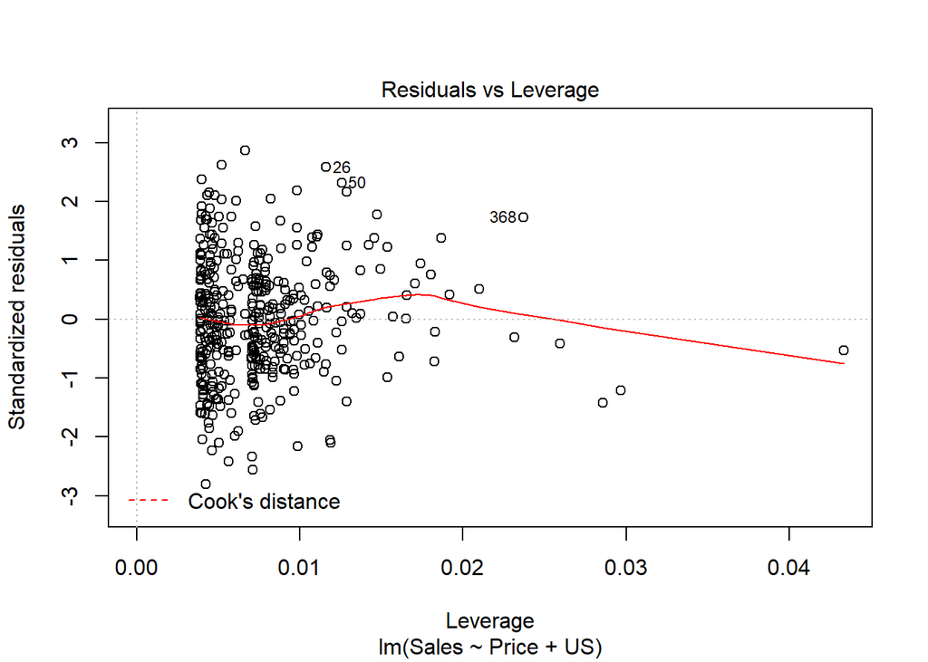

```r
plot(mult_cars_short, which = 5)
```

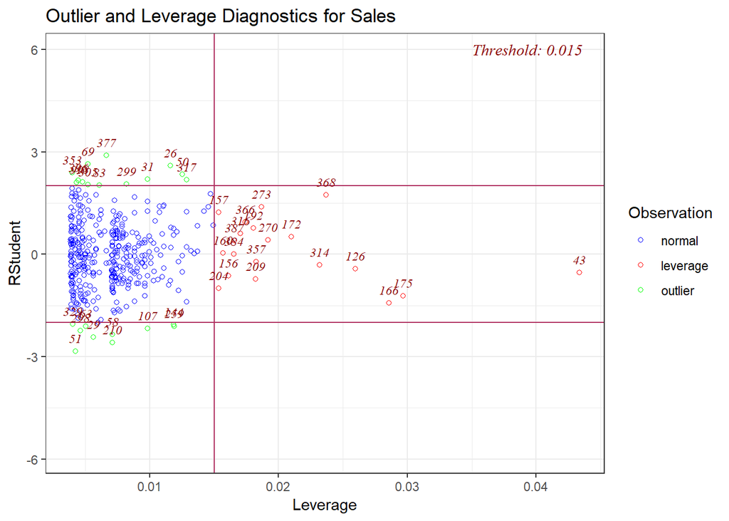

```r
ols_plot_resid_lev(mult_cars_short)
```

Yes there is evidence of outliers and high leverage observations (especially observation 43).

# Exercise 11

**In this problem we will investigate the t-statistic for the null hypothesis $H_0: \beta = 0$ in simple linear regression without an intercept. To begin, we generate a predictor `x` and a response `y` as follows.**

`set.seed(1)`

`x = rnorm(100)`

`y = 2*x + rnorm(100)`

**(a) Perform a simple linear regression of y onto x, without an intercept.** Report the coefficient estimate $\hat{\beta}$, the standard error of this coefficient estimate, and the t-statistic and p-value associated with the null hypothesis $H_0: \beta = 0$. Comment on these results. (You can perform regression without an intercept using the command `lm(y∼x+0)`.)

```r
set.seed(1)
x <- rnorm(100)
y <- 2*x + rnorm(100)

ex11 <- lm(y ~ x + 0)

summary(ex11)
```

```
##
## Call:
## lm(formula = y ~ x + 0)
##
## Residuals:
##     Min      1Q  Median      3Q     Max
## -1.9154 -0.6472 -0.1771  0.5056  2.3109
##
## Coefficients:
##   Estimate Std. Error t value Pr(>|t|)
## x   1.9939     0.1065   18.73   <2e-16 ***
## ---
## Signif. codes:  0 '***' 0.001 '**' 0.01 '*' 0.05 '.' 0.1 ' ' 1
##
## Residual standard error: 0.9586 on 99 degrees of freedom
## Multiple R-squared:  0.7798, Adjusted R-squared:  0.7776
## F-statistic: 350.7 on 1 and 99 DF,  p-value: < 2.2e-16
```

Coefficient estimate: 1.9938761

standard error: 0.1064767

t value: 18.7259319

p-value: 2.642196910^{-34}

The coefficient is close to the expected value of 2 and is statistically significant.

**(b) Now perform a simple linear regression of `x` onto `y` without an intercept, and report the coefficient estimate, its standard error, and the corresponding t-statistic and p-values associated with the null hypothesis $H_0: \beta = 0$. Comment on these results.**

```r
set.seed(1)
x <- rnorm(100)
y <- 2*x + rnorm(100)

ex11 <- lm(x ~ y + 0)

summary(ex11)
```

```
##
## Call:
## lm(formula = x ~ y + 0)
##
## Residuals:
##     Min      1Q  Median      3Q     Max
## -0.8699 -0.2368  0.1030  0.2858  0.8938
##
## Coefficients:
##   Estimate Std. Error t value Pr(>|t|)
## y  0.39111    0.02089   18.73   <2e-16 ***
## ---
## Signif. codes:  0 '***' 0.001 '**' 0.01 '*' 0.05 '.' 0.1 ' ' 1
##
## Residual standard error: 0.4246 on 99 degrees of freedom
## Multiple R-squared:  0.7798, Adjusted R-squared:  0.7776
## F-statistic: 350.7 on 1 and 99 DF,  p-value: < 2.2e-16
```

Coefficient estimate: 0.3911145

standard error: 0.0208863

t value: 18.7259319

p-value: 2.642196910^{-34}

The coefficient is statistically significant.

**(c) What is the relationship between the results obtained in (a) and (b)?**

The t values and p-values are the same in both cases. Interestingly, the coefficients are not inverses of each other (because of the noise added to y).

**(d) For the regression of Y onto X without an intercept, the tstatistic for $H_0: \beta = 0$ takes the form $\hat{\beta}/SE(\hat{\beta})$ … Show algebraically, and confirm numerically in R, that the t-statistic can be written as $\frac{(\sqrt{n-1})\Sigma_{i=1}^n x_iy_i}{\sqrt{(\Sigma_{i=1}^n x_i^2)(\Sigma_{i'=1}^n y_{i'}^2)-(\Sigma_{i'=1}^n x_{i'}y_{i'})^2}}$**

$\hat{\beta} = (\Sigma_{i=1}^n x_iy_i)/(\Sigma_{i'=1}^n x_{i'}^2)$

$SE(\hat{\beta}) = \sqrt{\frac{\Sigma_{i=1}^n(y_i-x_i\hat{\beta})^2}{(n-1)\Sigma_{i'=1}^n x_{i'}^2}}$

$t = \frac{\hat{\beta}}{SE(\hat{\beta})}$

Combining all three equations:

$t = \frac{(\Sigma_{i=1}^n x_iy_i)/(\Sigma_{i'=1}^n x_{i'}^2)}{\sqrt{(\Sigma_{i=1}^n(y_i-x_i\hat{\beta})^2})/\sqrt{(n-1)\Sigma_{i'=1}^n x_{i'}^2}}$

$t = \frac{\sqrt{(n-1)\Sigma_{i'=1}^n x_{i'}^2}(\Sigma_{i=1}^n x_iy_i)}{\sqrt{(\Sigma_{i=1}^n(y_i-x_i\hat{\beta})^2}(\Sigma_{i'=1}^n x_{i'}^2)}$

$t = \frac{\sqrt{(n-1)}(\Sigma_{i=1}^n x_iy_i)}{\sqrt{(\Sigma_{i=1}^n(y_i-x_i\hat{\beta})^2}\sqrt{(\Sigma_{i'=1}^n x_{i'}^2)}}$

**(e) Using the results from (d), argue that the t-statistic for the regression of `y` onto `x` is the same as the t-statistic for the regression of `x` onto `y`.**

$\frac{(\sqrt{n-1})\Sigma_{i=1}^n x_iy_i}{\sqrt{(\Sigma_{i=1}^n x_i^2)(\Sigma_{i'=1}^n y_{i'}^2)-(\Sigma_{i'=1}^n x_{i'}y_{i'})^2}} = \frac{(\sqrt{n-1})\Sigma_{i=1}^n y_ix_i}{\sqrt{(\Sigma_{i=1}^n y_i^2)(\Sigma_{i'=1}^n x_{i'}^2)-(\Sigma_{i'=1}^n y_{i'}x_{i'})^2}}$

**(f) In `R`, show that when regression is performed with an intercept, the t-statistic for $H_0: \beta_1 = 0$ is the same for the regression of `y` onto `x` as it is for the regression of `x` onto `y`.**

```r
set.seed(1)
x <- rnorm(100)
y <- 2*x + rnorm(100)

ex_with_int <- lm(y ~ x)

ex_with_int2 <- lm(x ~ y)
```

t-statistic for regression of `y` on `x`: 18.5555993

t-statistic for regression of `x` on `y`: 18.5555993

# Exercise 12

**This problem involves simple linear regression without an intercept.**

**(a) Recall that the coefficient estimate $\hat{\beta}$ for the linear regression of `Y` onto `X` without an intercept is given by (3.38). Under what circumstance is the coefficient estimate for the regression of `X` onto `Y` the same as the coefficient estimate for the regression of `Y` onto `X`?**

For the coefficient estimate for the regression of `X` onto `Y` to be the same as the coefficient estimate for the regression of `Y` onto `X` requires: $\frac{(\Sigma_{i=1}^n x_iy_i)}{(\Sigma_{i'=1}^n x_{i'}^2)} = \frac{(\Sigma_{i=1}^n y_ix_i)}{(\Sigma_{i'=1}^n y_{i'}^2)}$

Or equivalently, $(\Sigma_{i'=1}^n x_{i'}^2) = (\Sigma_{i'=1}^n y_{i'}^2)$.

**(b) Generate an example in `R` with `n = 100` observations in which the coefficient estimate for the regression of `X` onto `Y` is different from the coefficient estimate for the regression of `Y` onto `X`.**

```r
set.seed(1)
x <- 2*rnorm(100)
y <- rnorm(100)

coeff_diff1 <- lm(y ~ x + 0)

coeff_diff2 <- lm(x ~ y + 0)
```

**(c) Generate an example in R with n = 100 observations in which the coefficient estimate for the regression of `X` onto `Y` is the same as the coefficient estimate for the regression of `Y` onto `X`.**

```r
set.seed(1)
x <- rnorm(100)
y <- rev(x)

coeff_same1 <- lm(y ~ x + 0)

coeff_same2 <- lm(x ~ y + 0)
```

Coefficient estimate for regression of `X` onto `Y`: 0.0378511

Coefficient estimate for regression of `Y` onto `X`: 0.0378511

# Exercise 13

**In this exercise you will create some simulated data and will fit simple linear regression models to it. Make sure to use set.seed(1) prior to starting part (a) to ensure consistent results.**

**(a) Using the `rnorm()` function, create a vector, `x`, containing 100 observations drawn from a N(0,1) distribution. This represents a feature, `X`.**

```r
set.seed(1)
X <- rnorm(100)
```

**(b) Using the rnorm() function, create a vector, eps, containing 100 observations drawn from a N(0, 0.25) distribution i.e. a normal distribution with mean zero and variance 0.25.**

```r
eps <- rnorm(100, 0, sqrt(0.25))
```

**(c) Using `x` and `eps`, generate a vector `y` according to the model** $Y = −1 + 0.5X + \epsilon$

```r
Y <- −1 + 0.5*X + eps
```

**What is the length of the vector `y`? What are the values of $\beta_0$ and $\beta_1$ in this linear model?**

Y is 100 elements long, $\beta_0 = -1$ and $\beta_1 = 0.5$.

**(d) Create a scatterplot displaying the relationship between `x` and `y`. Comment on what you observe.**

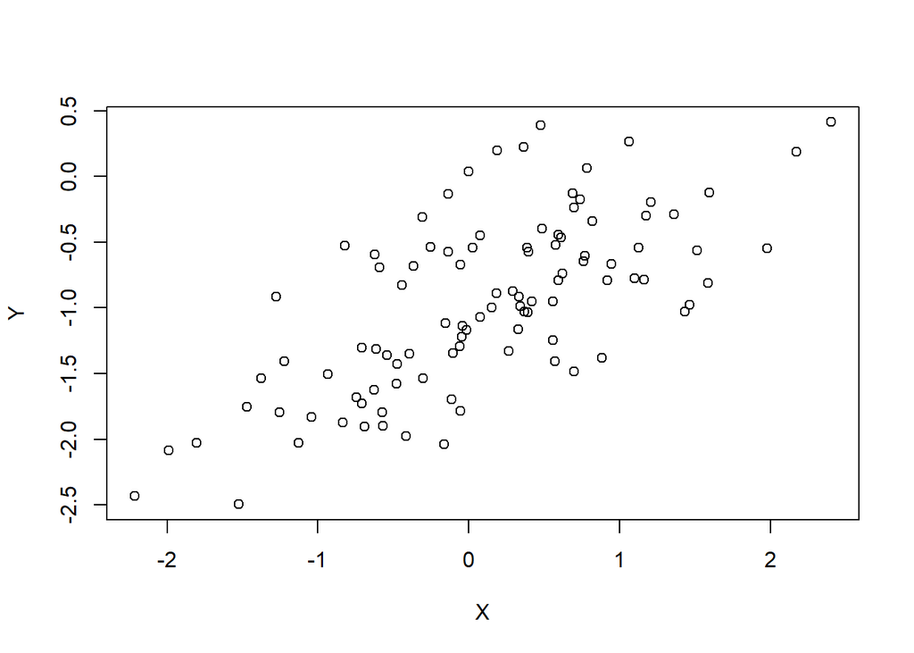

```r
plot(X,Y)
```

**(e) Fit a least squares linear model to predict y using x. Comment on the model obtained. How do $\hat{\beta_0}$ and $\hat{\beta_1}$ compare to $\beta_0$ and $\beta_1$?**

```r
med_error <- lm(Y ~ X)

summary(med_error)
```

```
##
## Call:
## lm(formula = Y ~ X)
##
## Residuals:
##      Min       1Q   Median       3Q      Max
## -0.93842 -0.30688 -0.06975  0.26970  1.17309
##
## Coefficients:
##             Estimate Std. Error t value Pr(>|t|)
## (Intercept) -1.01885    0.04849 -21.010  < 2e-16 ***
## X            0.49947    0.05386   9.273 4.58e-15 ***
## ---
## Signif. codes:  0 '***' 0.001 '**' 0.01 '*' 0.05 '.' 0.1 ' ' 1
##
## Residual standard error: 0.4814 on 98 degrees of freedom
## Multiple R-squared:  0.4674, Adjusted R-squared:  0.4619
## F-statistic: 85.99 on 1 and 98 DF,  p-value: 4.583e-15
```

$\hat{\beta_0}$ and $\beta_0$ are very similar (-1.019 versus -1), and so are $\hat{\beta_1}$ and $\beta_1$ (0.499 versus 0.5).

**(f) Display the least squares line on the scatterplot obtained in (d). Draw the population regression line on the plot, in a different color. Use the `legend()` command to create an appropriate legend.**

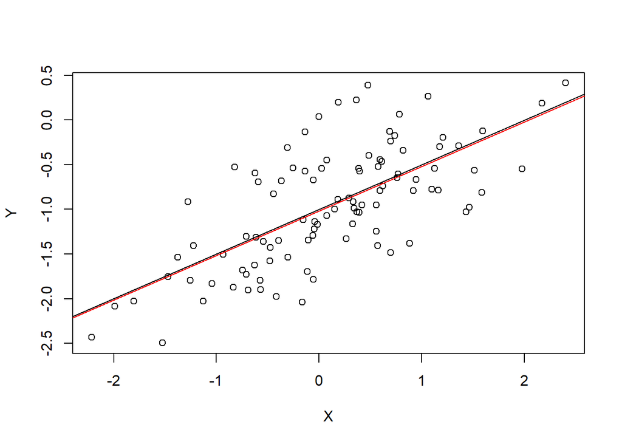

```r
plot(X,Y)
abline(med_error, col = "red")
abline(a = -1, b = 0.5, col = "black")
```

```r
#legend("topleft")
```

The regression line (red) is almost identical to the true line (black).

**(g) Now fit a polynomial regression model that predicts `y` using `x` and `x2`. Is there evidence that the quadratic term improves the model fit? Explain your answer.**

```r
med_error_quad <- lm(Y ~ X + I(X^2))

summary(med_error_quad)
```

```
##
## Call:
## lm(formula = Y ~ X + I(X^2))
##
## Residuals:
##      Min       1Q   Median       3Q      Max
## -0.98252 -0.31270 -0.06441  0.29014  1.13500
##
## Coefficients:
##             Estimate Std. Error t value Pr(>|t|)
## (Intercept) -0.97164    0.05883 -16.517  < 2e-16 ***
## X            0.50858    0.05399   9.420  2.4e-15 ***
## I(X^2)      -0.05946    0.04238  -1.403    0.164
## ---
## Signif. codes:  0 '***' 0.001 '**' 0.01 '*' 0.05 '.' 0.1 ' ' 1
##
## Residual standard error: 0.479 on 97 degrees of freedom
## Multiple R-squared:  0.4779, Adjusted R-squared:  0.4672
## F-statistic:  44.4 on 2 and 97 DF,  p-value: 2.038e-14
```

No there is not evidence that the quadratic term improves the model. It is not statistically significant, the adjusted $R^2$ values and the residual standard errors for the two models are almost identical.

**(h) Repeat (a)–(f) after modifying the data generation process in such a way that there is less noise in the data. The model (3.39) should remain the same. You can do this by decreasing the variance of the normal distribution used to generate the error term $\epsilon$ in (b). Describe your results.**

```r
set.seed(1)
X <- rnorm(100)
eps <- rnorm(100, 0, sqrt(0.1))
Y <- −1 + 0.5*X + eps

low_error <- lm(Y ~ X)
summary(low_error)
```

```
##
## Call:
## lm(formula = Y ~ X)
##
## Residuals:
##      Min       1Q   Median       3Q      Max
## -0.59351 -0.19409 -0.04411  0.17057  0.74193
##
## Coefficients:
##             Estimate Std. Error t value Pr(>|t|)
## (Intercept) -1.01192    0.03067  -32.99   <2e-16 ***
## X            0.49966    0.03407   14.67   <2e-16 ***
## ---
## Signif. codes:  0 '***' 0.001 '**' 0.01 '*' 0.05 '.' 0.1 ' ' 1
##
## Residual standard error: 0.3044 on 98 degrees of freedom
## Multiple R-squared:  0.687,  Adjusted R-squared:  0.6838
## F-statistic: 215.1 on 1 and 98 DF,  p-value: < 2.2e-16
```

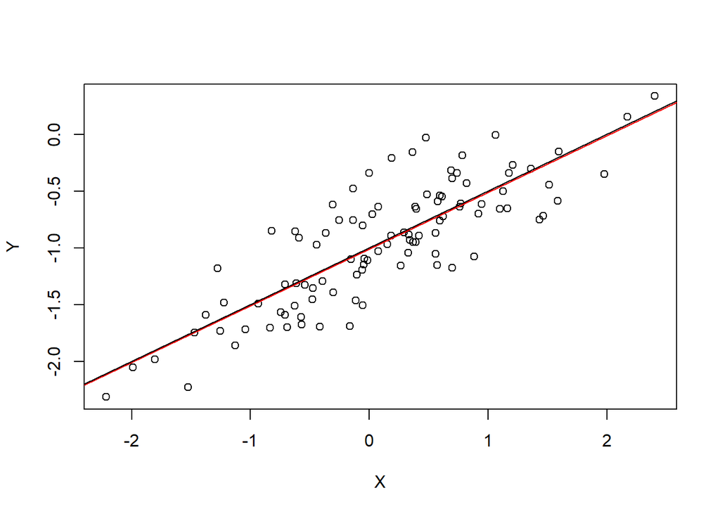

```r
plot(X,Y)
abline(low_error, col = "red")
abline(a = -1, b = 0.5, col = "black")
```

The estimated and actual parameters are even closer. $\hat{\beta_0}$ and $\beta_0$ are very similar (-1.012 versus -1), and so are $\hat{\beta_1}$ and $\beta_1$ (0.500 versus 0.5).

**(i) Repeat (a)–(f) after modifying the data generation process in such a way that there is more noise in the data. The model (3.39) should remain the same. You can do this by increasing the variance of the normal distribution used to generate the error term $\epsilon$ in (b). Describe your results.**

```r
set.seed(1)
X <- rnorm(100)
eps <- rnorm(100, 0, 10)
Y <- −1 + 0.5*X + eps

high_error <- lm(Y ~ X)
summary(high_error)
```

```
##
## Call:
## lm(formula = Y ~ X)
##
## Residuals:
##     Min      1Q  Median      3Q     Max
## -18.768  -6.138  -1.395   5.394  23.462
##
## Coefficients:
##             Estimate Std. Error t value Pr(>|t|)
## (Intercept)  -1.3769     0.9699  -1.420    0.159
## X             0.4894     1.0773   0.454    0.651
##
## Residual standard error: 9.628 on 98 degrees of freedom
## Multiple R-squared:  0.002102,   Adjusted R-squared:  -0.008081
## F-statistic: 0.2064 on 1 and 98 DF,  p-value: 0.6506
```

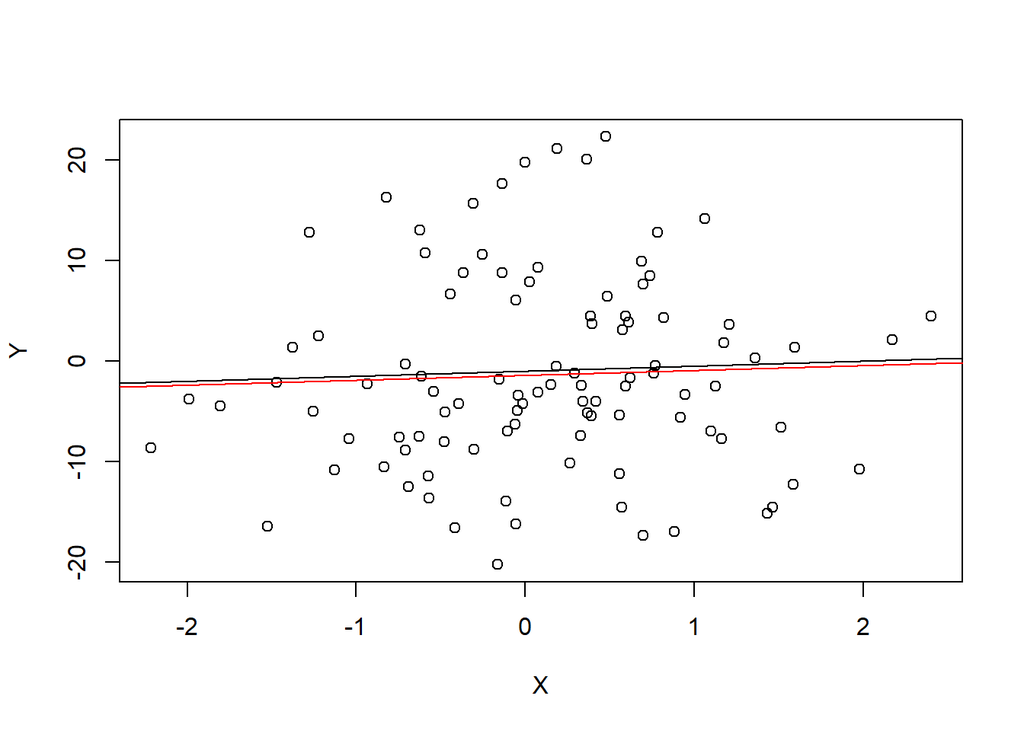

```r
plot(X,Y)
abline(high_error, col = "red")
abline(a = -1, b = 0.5, col = "black")
```

**(j) What are the confidence intervals for $\beta_0$ and $\beta_1$ based on the original data set, the noisier data set, and the less noisy data set? Comment on your results.**

```r
confint(low_error)
```

```
##                  2.5 %     97.5 %
## (Intercept) -1.0727832 -0.9510557
## X            0.4320613  0.5672681
```

```r
confint(med_error)
```

```
##                  2.5 %     97.5 %
## (Intercept) -1.1150804 -0.9226122
## X            0.3925794  0.6063602
```

```r
confint(high_error)
```

```
##                 2.5 %    97.5 %
## (Intercept) -3.301607 0.5477552
## X           -1.648412 2.6272040
```

The more noisy the data, the wider the confidence intervals. THe high noise model confidence intervals include zero.